# DA HW3 Summary_report

Gyebnar Daniel

2022 02 15

# Assessment of fast growing firms

## Abstract

FastInvest aims to invest EUR 100,000 in firms identified as fast growing. Based on their investment policy they purchase firms that are expected to grow by at lest 50% annually, and hold them for 5 years before realizing the profit from selling.

The goal of this project was to identify firms with such potential using the tools of prediction and classification by using logit, lasso, and random forest models. This report details summarise key results and the modeling process in a high level.

## Executive summary

The task was to select fast growing firms, defined as firms growing at least 50% annually.

The data was used for this analysis was collected, maintained, and cleaned by Bisnode. I defined fast growing as having at least a 50% annual growth in the 2012-2014 period. For this, I buil Logit, LASSO, and Random Forest models for predicting porbability of a firm being “fast growth”.

I defined the loss function with False Negatives being 7 times worse as False Positives, based on the opportunity of realizing 50% annual growth on the initial investment of EUR 100,000 for 5 years of holding period leading to 700,000 in profits. I set the threshold with the help of the loss function to find the optimal threshold for classification.

| X | Number.of.predictors | CV.RMSE | CV.AUC |
| --- | --- | --- | --- |
| X1 | 5 | 0.2988625 | 0.7311906 |
| X2 | 12 | 0.2935743 | 0.7620098 |
| X3 | 30 | 0.2907820 | 0.7796409 |
| X4 | 72 | 0.2913913 | 0.7807557 |
| X5 | 85 | 0.2906602 | 0.7804243 |
| LASSO | 70 | 0.2897130 | 0.7583547 |

The accuracy of the model was 71% meaning that is classified 71% of the firms into the correct categoryand identified not fast growing firms 71.1% correctly, while from the actual fast growing ones it predicted 72.6% right.

From the firms the model predicted to be fast growing 24% actually turned out to be fast growing. This is more than twice as high as the occurance of fast growing firms in a random sample (11%)

#### Data cleaning process

The data originally had c.290,000 observations on c.46,000 firms from 2005 to 2016, with 48 variables. In the end of data cleaning I ended up with 14,139 observations (each a firm from 2012) and 116 variables.

#### Selecting observations

I filtered the data for the 2010-2015 period, and included firms with a revenue between EUR 1,000 - 1,000,000 to capture SMEs. I excluded observations of firms that are no longer active, and also restricted the firms to 2012 (base year of prediction), and below CAGR of 3000 (to exclude potential mistakes and unprecedented events of growth that are not likely to be repeated in case of a purchase)

#### Adding new variables

I added explanatory variables, such as log sales, previous CAGRs (2010-’11 and 2011-’12), foreign management variable and CEO age. I included ratios for key financials by dividing all balance sheet elements with total assets, and similarly with profit and loss statement elements.

### Droping variables, Imputation corrections

I dropped variables that had too many missing values (above 15,000 in raw dataset). I used winsorization to correct values for certain items that are not possible based on domain knowledge, and flagged them.

In the end, I had the following distributions:

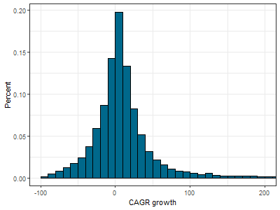

Histogram of CAGR

#### Modeling

I created 3 types of models: logit, LASSO and Random Forest. First I predicted the probabilities of firm being fast-growing or not, using 5-fold cross-validation on the training set. I selected preferred models, and used a loss function and a threshold to categorize the prediction results into fast growing / not fast growing. I evaluated the model with the smallest loss on the holdout set as a final result, and created the confusion matrix for evaluation.

#### Results with no loss function

I created a holdout set from the 20% of the data. The total set, the holdout set and the train set as well had a c.11% ratio of fast growing firms. The train data was used for a 5-fold cross validation.

#### Results with loss function

Based on the formula the optimal classification threshold would be 1/(1+7) = 0.125, but also used an algorithm to calculate optimal thresholds. The results can be found below:

| X | Number.of.predictors | CV.RMSE | CV.AUC | CV.threshold | CV.expected.Loss |
| --- | --- | --- | --- | --- | --- |
| Logit X1 | 5 | 0.2988625 | 0.7311906 | 0.1011677 | 2.117984 |
| Logit X3 | 30 | 0.2907820 | 0.7796409 | 0.1075261 | 1.797321 |
| Logit LASSO | 70 | 0.2897130 | 0.7583547 | 0.1060399 | 2.149361 |
| RF probability | 35 | 0.2901506 | 0.7771989 | 0.1280486 | 1.706769 |

#### Model choice and evaluation

Based table expected loss in the table above, the Random Forest is the best model to use due to lowest expected losses, followed by Logit X3. Interestingly, ordering the models based on AUC would yield a different list

| X | fast_growth | no_fast_growth |
| --- | --- | --- |
| fast_growth | 228 | 727 |
| no_fast_growth | 86 | 1786 |

Accuracy is 71.2% Sensitivity is 72.6% Specificity is 71.1% Correctly predicted positive 23.9%